# My Report

### Introduction

I chose to focus on the ‘us-prison-pop.csv’ for this assignment. Within this, I wanted to focus on Washington State because that’s where I am from! I then weeded that down to only the most populated counties in Washington State. The variables that I chose to work with included female prison population, black population and black prison population. I chose these variables as I believed I would find more relevant data within marginalized groups.

### Summary Information

After sorting through data, I chose to find some averages to set the tone for the research. Again, I focused on Washington State, and thus chose to find averages among counties. The average population among counties in 2016 was 426,861 people and the average prison population was 994. Meaning, about 0.233% of all people in those counties were incarcerated. As for women between 15-64 only, the average population among Washington counties was 142,068. Their average population in prison was 76, meaning 0.0535% women in those counties were incarcerated. With 142,068/426,861 = 33.282% of the average population but 76/994 = 7.646% of the average prison population, I am not surprised. Anyone giving a quick look over the data could see that men are incarcerated at much higher rates. Although women are a marginalized group, it doesn’t seem to apply to prison. I next chose to find the highest and lowest values for female and black prison populations. I found that the highest black population in prison occurred in King County in 2002 and was 1,845. Out of 73,480, this means that 2.511% of were incarcerated that year, much higher than the 2016 average of 0.233%. The highest female prison population occurred in Pierce County in 2009 and was 297. Out of 272,547, this means that 0.109% were incarcerated that year, double the average in 2016 of 0.0535%. The lowest for both variables occurred simultaneously in Adams County in 1993 and was 0 for both. This year, Adams County only contained 14 total inmates, thus it was an odd year. There must have been an event that occurred that year that caused such a low prison population.

Average Total Population: 426860.5 Average Total Prison Population: 994.3636 Average Female Prison Population: 75.81818 Average Female Population (15-64): 142068.1

Highest Black Prison Pop: 1845, King County 2002 Highest Female Prison Pop: 297, Pierce County 2009 Lowest Black Prison Pop: 0, Adams County 1993 (14 total in prison) Lowest Female Prison Pop: 0, Adams County 1993 (14 total in prison)

### The Dataset

-Vera Institute collected the data -Vera uses the Incarceration Trends data tool which uses data from the Bureau of Justice Statistics, Census of Jails and Annual Survey of Jails. -The data was collected to confront discrimination and disparities in the prison system as well as promote the growth of it. -There are 153,811 rows (‘us-prison-pop.csv’). -There are 36 (‘us-prison-pop.csv’). -You must ask yourself if there are any disparities in the groups in and not in the prison population, as well as who has the power to create these situations and actually place citizens in prison? Lastly, how much missing data is there from marginalized groups that were failed to be reported?

What are possible limitations or problems with this data? (at least 200 words)

-Immediately after loading the data into R, it is evident that there is a lot of missing values replaced by NA that need to be filtered out before finding any trends or coming to any conclusions. This was the first thing I did before proceeding to embark on this assignment. Also the data that I worked with in ‘us-prison-pop.csv’ was only updated to 2016, meaning there is 7 years of missing data. This last 7 years has been monumental in the push and pull of racial tension and the pursuit of equity. I believe that there could be an upward trend in the growth of the prison system since 2016. Another limitation could be how the data was collected. It was compiled from 3 official sources, but still mass data like this can be very difficult to collect and organize accurately. I would wager that there are definite errors in the numbers I worked with, however this is the case for just about any data set one may work with. I also noticed that when finding total populations for each group of people, they only accounted for the ages between 15 and 64. Under 15 may be mostly irrelevant, but there are definitely prisoners and members of the population who are liable to go to jail, all over 64.

### Trends Over Time Chart

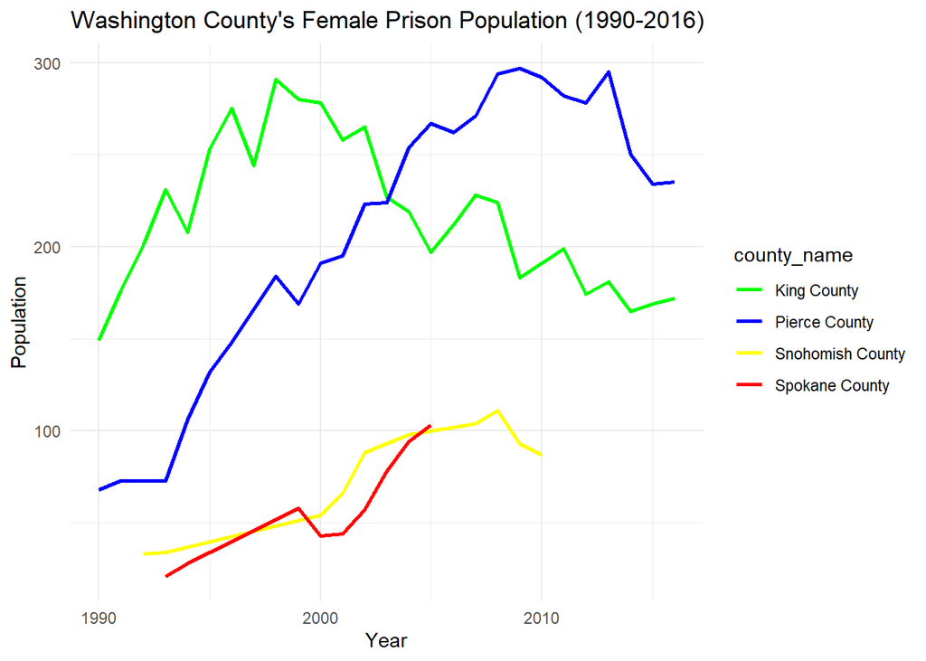

### Variable Comparison Chart

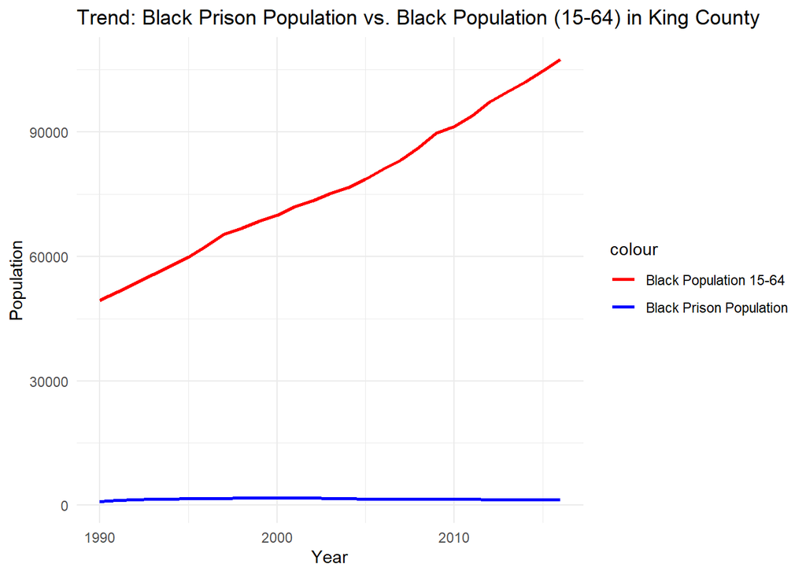

For my variable comparison chart I chose to evaluate the relationship between the black population of King County and its black population in prison. I wanted to find out if and slightly expected there to be a definite relation between the two and maybe even a steeper slope on the line representing the prisoners. However, I found that as the black population rapidly grew from 1990 to 2016, the population in prison stayed very steady. It seems that although the two variables are very much related, the population in prison does not seem to be affected much by the total population.

### Map

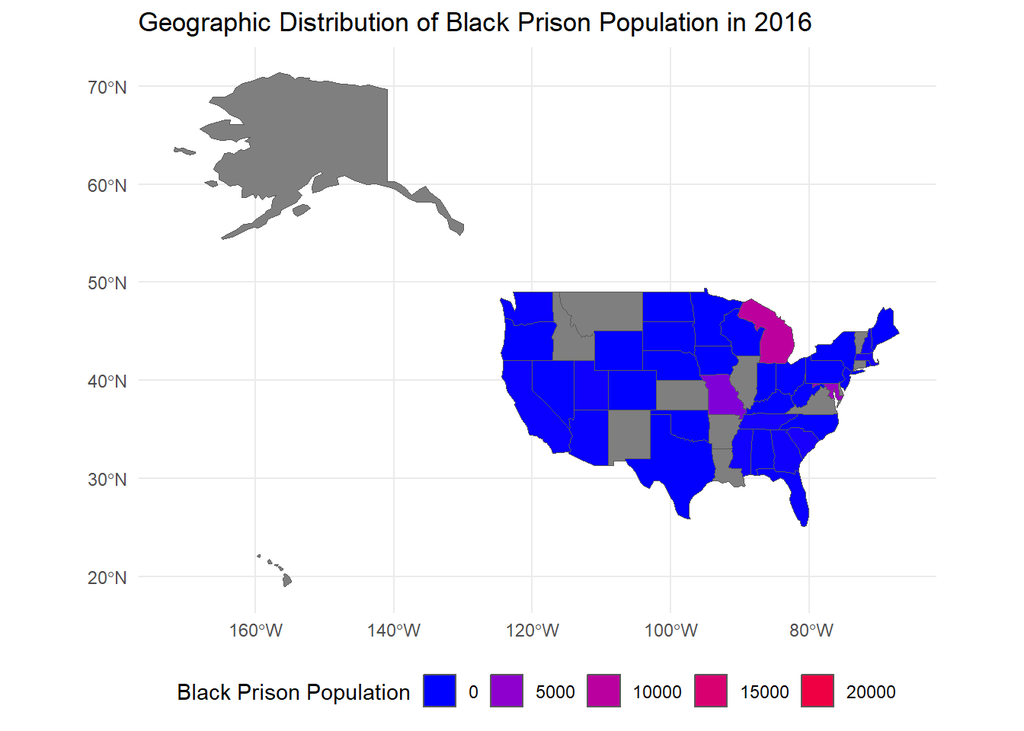